# Regression

## 2.3 Model selection criteria

越大越好  
1. R2(拟合角度)  
2. adj.R2(一般用summary可以调用)()  
越小越好  
3. $C_p$值,$C_p=\frac{1}{n}(RSS+2k\hat{\sigma}^{2})$,k是变量个数,$\hat{\sigma}^{2}$是误差项估计量的方差,越小越好(预测角度)  
4. $AIC=(\frac{2k}{n})+ln(\frac{RSS}{n})$(极大似然估计角度)

```r
#mod1 = lm(y ~ x1 + ... + xk, data=ds)
#AIC(mod1)
```

```r
#library(nlme)
#mod1 = lm(y ~ x1 + ... + xk, data=ds)
#BIC(mod1)
```

## 2.4 Best Subset Selection最优子集法

k个变量中选出i个变量做回归,有$k \choose i$个模型,找出最好的那i个变量  
i从1到k都取一遍  
每个模型都是选出i个变量的时候,$k \choose i$个模型中RSS最小的模型($R^{2}$最大)

```r
library(ISLR)
names(Hitters)
```

```
##  [1] "AtBat"     "Hits"      "HmRun"     "Runs"      "RBI"
##  [6] "Walks"     "Years"     "CAtBat"    "CHits"     "CHmRun"
## [11] "CRuns"     "CRBI"      "CWalks"    "League"    "Division"
## [16] "PutOuts"   "Assists"   "Errors"    "Salary"    "NewLeague"
```

```r
dim(Hitters)
```

```
## [1] 322  20
```

```r
#去掉缺失值
sum(is.na(Hitters$Salary))
```

```
## [1] 59
```

```r
Hitters=na.omit(Hitters)
dim(Hitters)
```

```
## [1] 263  20
```

```r
sum(is.na(Hitters))
```

```
## [1] 0
```

```r
library(leaps)
#salary做y,其他做x,基于Best Subset Selection方法,找出19个回归模型出来
regfit.full=regsubsets(Salary~.,data=Hitters,nvmax=19)
reg.summary=summary(regfit.full)
#返回的项目
names(reg.summary)
```

```
## [1] "which"  "rsq"    "rss"    "adjr2"  "cp"     "bic"    "outmat" "obj"
```

```r
#每个模型的adjr2,cp,bic
reg.summary$adjr2
```

```
##  [1] 0.319 0.421 0.445 0.467 0.481 0.497 0.501 0.514 0.518 0.522 0.523
## [12] 0.522 0.521 0.520 0.518 0.516 0.514 0.513 0.511
```

```r
reg.summary$cp
```

```
##  [1] 104.28  50.72  38.69  27.86  21.61  14.02  13.13   7.40   6.16   5.01
## [11]   5.87   7.33   8.89  10.48  12.35  14.19  16.09  18.01  20.00
```

```r
reg.summary$bic
```

```
##  [1]  -90.8 -128.9 -135.6 -141.8 -144.1 -147.9 -145.3 -147.6 -145.4 -143.2
## [11] -138.9 -133.9 -128.8 -123.6 -118.2 -112.8 -107.4 -101.9  -96.3
```

```r
#windows(7,7)
par(mfrow=c(2,2))
#RSS与变量个数关系
plot(reg.summary$rss,xlab="Number of Variables",ylab="RSS",type="l")
#adjr2与变量个数的关系
plot(reg.summary$adjr2,xlab="Number of Variables",ylab="Adjusted RSq",type="l")
#找出adjr2最大的模型
which.max(reg.summary$adjr2)
```

```
## [1] 11
```

```r
#在图上红色标注
points(11,reg.summary$adjr2[11], col="red",cex=2,pch=20)
#cp值与变量个数关系
plot(reg.summary$cp,xlab="Number of Variables",ylab="Cp",type='l')
#找出cp值最小的模型
which.min(reg.summary$cp)
```

```
## [1] 10
```

```r
#标点
points(10,reg.summary$cp[10],col="red",cex=2,pch=20)
#找出bic最小
which.min(reg.summary$bic)
```

```
## [1] 6
```

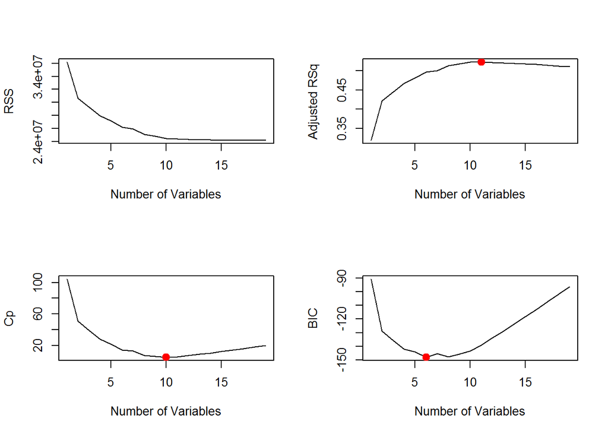

```r
#bic与变量个数关系
plot(reg.summary$bic,xlab="Number of Variables",ylab="BIC",type='l')
#标点
points(6,reg.summary$bic[6],col="red",cex=2,pch=20)
```

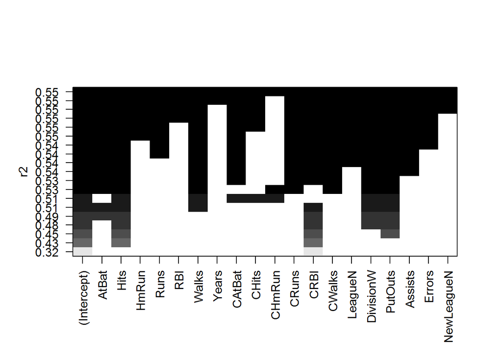

```r
#par(mfrow=c(2,2))
#行代表这个模型对应的判断标准值,列代表变量
#色块代表选择对应变量集合的时候生成的模型,是该变量集合的变量个数下RSS最小的模型,并对应一个指标值
#左边轴的数字可能会相同是因为精度的问题,事实上只有最上方的是最好的
#色块原理:把灰度0-1按纵轴最小到最大的间隔等分,然后每个模型对应的纵轴值对应一个灰度值
par(mfrow=c(1,1))
plot(regfit.full,scale="r2")
```

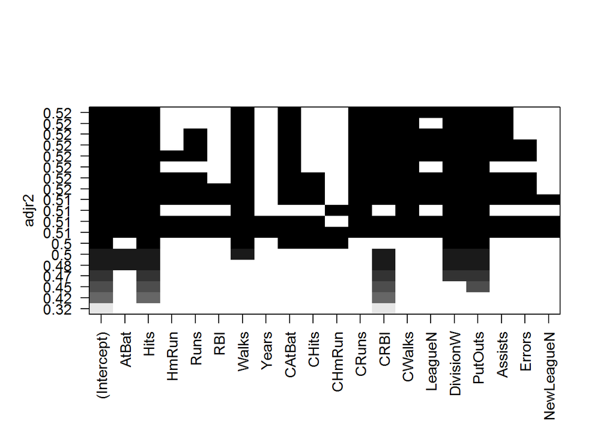

```r
plot(regfit.full,scale="adjr2")
```

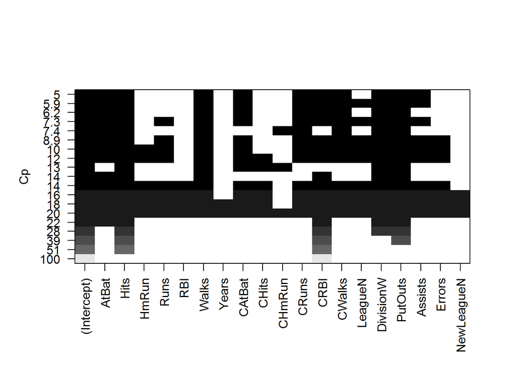

```r
plot(regfit.full,scale="Cp")
```

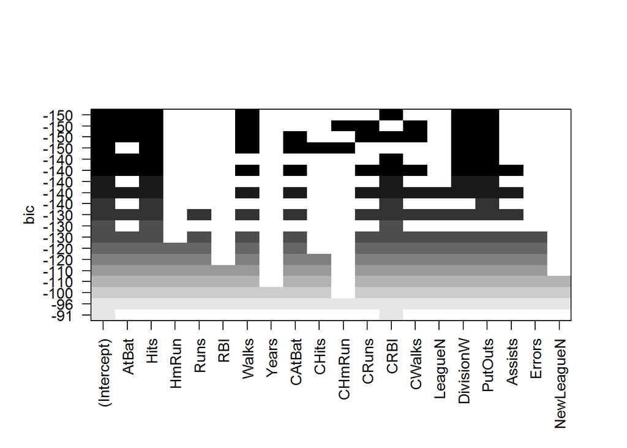

```r
plot(regfit.full,scale="bic")
```

```r
#返回6个变量时最佳模型的系数
coef(regfit.full,6)
```

```
## (Intercept)       AtBat        Hits       Walks        CRBI   DivisionW
##      91.512      -1.869       7.604       3.698       0.643    -122.952
##     PutOuts
##       0.264
```

## 2.5 Stepwise逐步回归

- 向前-从空模型开始逐个加入
- 向后-从全模型开始逐个剔除(要求变量总个数小于样本数)
- 混合

```r
cement<-data.frame( X1=c( 7, 1, 11, 11, 7, 11, 3, 1, 2, 21, 1, 11, 10),
X2=c(26, 29, 56, 31, 52, 55, 71, 31, 54, 47, 40, 66, 68),
X3=c( 6, 15, 8, 8, 6, 9, 17, 22, 18, 4, 23, 9, 8),
X4=c(60, 52, 20, 47, 33, 22, 6, 44, 22, 26, 34, 12, 12),
Y =c(78.5, 74.3, 104.3, 87.6, 95.9, 109.2, 102.7, 72.5, 93.1,115.9, 83.8, 113.3, 109.4)
)
lm.sol<-lm(Y ~ X1+X2+X3+X4, data=cement)
summary(lm.sol)
```

```
##
## Call:
## lm(formula = Y ~ X1 + X2 + X3 + X4, data = cement)
##
## Residuals:
##    Min     1Q Median     3Q    Max
## -3.175 -1.671  0.251  1.378  3.925
##
## Coefficients:
##             Estimate Std. Error t value Pr(>|t|)
## (Intercept)   62.405     70.071    0.89    0.399
## X1             1.551      0.745    2.08    0.071 .
## X2             0.510      0.724    0.70    0.501
## X3             0.102      0.755    0.14    0.896
## X4            -0.144      0.709   -0.20    0.844
## ---
## Signif. codes:  0 '***' 0.001 '**' 0.01 '*' 0.05 '.' 0.1 ' ' 1
##
## Residual standard error: 2.45 on 8 degrees of freedom
## Multiple R-squared:  0.982,  Adjusted R-squared:  0.974
## F-statistic:  111 on 4 and 8 DF,  p-value: 4.76e-07
```

```r
#全部不显著但是r2非常大,有共线性
#逐步删去,按照AIC准则,每行代表去掉这个变量的数据,none代表不去掉,当none的AIC最小时停止
lm.step<-step(lm.sol)
```

```
## Start:  AIC=26.9
## Y ~ X1 + X2 + X3 + X4
##
##        Df Sum of Sq  RSS  AIC
## - X3    1      0.11 48.0 25.0
## - X4    1      0.25 48.1 25.0
## - X2    1      2.97 50.8 25.7
## <none>              47.9 26.9
## - X1    1     25.95 73.8 30.6
##
## Step:  AIC=25
## Y ~ X1 + X2 + X4
##
##        Df Sum of Sq RSS  AIC
## <none>               48 25.0
## - X4    1        10  58 25.4
## - X2    1        27  75 28.7
## - X1    1       821 869 60.6
```

```r
summary(lm.step)
```

```
##
## Call:
## lm(formula = Y ~ X1 + X2 + X4, data = cement)
##
## Residuals:
##    Min     1Q Median     3Q    Max
## -3.092 -1.802  0.256  1.282  3.898
##
## Coefficients:
##             Estimate Std. Error t value Pr(>|t|)
## (Intercept)   71.648     14.142    5.07  0.00068 ***
## X1             1.452      0.117   12.41  5.8e-07 ***
## X2             0.416      0.186    2.24  0.05169 .
## X4            -0.237      0.173   -1.37  0.20540
## ---
## Signif. codes:  0 '***' 0.001 '**' 0.01 '*' 0.05 '.' 0.1 ' ' 1
##
## Residual standard error: 2.31 on 9 degrees of freedom
## Multiple R-squared:  0.982,  Adjusted R-squared:  0.976
## F-statistic:  167 on 3 and 9 DF,  p-value: 3.32e-08
```

```r
#返回去掉一个变量的结果
drop1(lm.step)
```

```
## Single term deletions
##
## Model:
## Y ~ X1 + X2 + X4
##        Df Sum of Sq RSS  AIC
## <none>               48 25.0
## X1      1       821 869 60.6
## X2      1        27  75 28.7
## X4      1        10  58 25.4
```

```r
#最终
lm.opt<-lm(Y ~ X1+X2, data=cement); summary(lm.opt)
```

```
##
## Call:
## lm(formula = Y ~ X1 + X2, data = cement)
##
## Residuals:
##    Min     1Q Median     3Q    Max
##  -2.89  -1.57  -1.30   1.36   4.05
##
## Coefficients:
##             Estimate Std. Error t value Pr(>|t|)
## (Intercept)  52.5773     2.2862    23.0  5.5e-10 ***
## X1            1.4683     0.1213    12.1  2.7e-07 ***
## X2            0.6623     0.0459    14.4  5.0e-08 ***
## ---
## Signif. codes:  0 '***' 0.001 '**' 0.01 '*' 0.05 '.' 0.1 ' ' 1
##
## Residual standard error: 2.41 on 10 degrees of freedom
## Multiple R-squared:  0.979,  Adjusted R-squared:  0.974
## F-statistic:  230 on 2 and 10 DF,  p-value: 4.41e-09
```

## 2.6 更新模型

```r
x1=rnorm(100)
x2=rnorm(100)
x3=rnorm(100)
y=rnorm(100)
fm2 <- lm(y ~ x1 + x2)
#加入x3变量
fm3 <- update(fm2, . ~ . + x3)
#加入y2项
smf3 <- update(fm3, I(y^2) ~ .)
```